# Project: Investigate a Dataset (Tmdb_Movies DataSet)

- Introduction
- Data Wrangling
- Exploratory Data Analysis
- Conclusions

## Introduction

### Overview

> In this report we will make data analysis for the Tmdb movie data set to answer some questions, This data set consists of 10K samples and 21 features/columns.

### Questions

> 1. What genres are the Most Popular?
> 2. What genres have the longest and shortest runtime?
> 3. What genres have the highest rate?
> 4. What genres have the highest budget?
> 5. What genres have the highest revenue?
> 6. What genres have the highest profit?
> 7. Relation between popularity and profit?
> 8. Relation between budget and profit?
> 9. Is the movie industry profit increase with years?
> 10. What is the relation between budget and release years?
> 11. Average profit of movies?
> 12. Average Budget of successful movies?

```python
# import needed all packages
import pandas as pd
import numpy as np
import matplotlib.pyplot as plt
from matplotlib.pyplot import figure
```

## Data Wrangling

> In this section of the report, we will load the data set and explore its general properties to find problems in the data to be fixed or cleaned.

### load data

```python
# load data
df = pd.read_csv('DataSet/tmdb-movies.csv')
```

```python
df.head()
```

|  | id | imdb_id | popularity | budget | revenue | original_title | cast | homepage | director | tagline | ... | overview | runtime | genres | production_companies | release_date | vote_count | vote_average | release_year | budget_adj | revenue_adj |
| --- | --- | --- | --- | --- | --- | --- | --- | --- | --- | --- | --- | --- | --- | --- | --- | --- | --- | --- | --- | --- | --- |
| 0 | 135397 | tt0369610 | 32.985763 | 150000000 | 1513528810 | Jurassic World | Chris Pratt\|Bryce Dallas Howard\|Irrfan Khan\|Vi... | http://www.jurassicworld.com/ | Colin Trevorrow | The park is open. | ... | Twenty-two years after the events of Jurassic ... | 124 | Action\|Adventure\|Science Fiction\|Thriller | Universal Studios\|Amblin Entertainment\|Legenda... | 6/9/15 | 5562 | 6.5 | 2015 | 1.379999e+08 | 1.392446e+09 |
| 1 | 76341 | tt1392190 | 28.419936 | 150000000 | 378436354 | Mad Max: Fury Road | Tom Hardy\|Charlize Theron\|Hugh Keays-Byrne\|Nic... | http://www.madmaxmovie.com/ | George Miller | What a Lovely Day. | ... | An apocalyptic story set in the furthest reach... | 120 | Action\|Adventure\|Science Fiction\|Thriller | Village Roadshow Pictures\|Kennedy Miller Produ... | 5/13/15 | 6185 | 7.1 | 2015 | 1.379999e+08 | 3.481613e+08 |
| 2 | 262500 | tt2908446 | 13.112507 | 110000000 | 295238201 | Insurgent | Shailene Woodley\|Theo James\|Kate Winslet\|Ansel... | http://www.thedivergentseries.movie/#insurgent | Robert Schwentke | One Choice Can Destroy You | ... | Beatrice Prior must confront her inner demons ... | 119 | Adventure\|Science Fiction\|Thriller | Summit Entertainment\|Mandeville Films\|Red Wago... | 3/18/15 | 2480 | 6.3 | 2015 | 1.012000e+08 | 2.716190e+08 |
| 3 | 140607 | tt2488496 | 11.173104 | 200000000 | 2068178225 | Star Wars: The Force Awakens | Harrison Ford\|Mark Hamill\|Carrie Fisher\|Adam D... | http://www.starwars.com/films/star-wars-episod... | J.J. Abrams | Every generation has a story. | ... | Thirty years after defeating the Galactic Empi... | 136 | Action\|Adventure\|Science Fiction\|Fantasy | Lucasfilm\|Truenorth Productions\|Bad Robot | 12/15/15 | 5292 | 7.5 | 2015 | 1.839999e+08 | 1.902723e+09 |
| 4 | 168259 | tt2820852 | 9.335014 | 190000000 | 1506249360 | Furious 7 | Vin Diesel\|Paul Walker\|Jason Statham\|Michelle ... | http://www.furious7.com/ | James Wan | Vengeance Hits Home | ... | Deckard Shaw seeks revenge against Dominic Tor... | 137 | Action\|Crime\|Thriller | Universal Pictures\|Original Film\|Media Rights ... | 4/1/15 | 2947 | 7.3 | 2015 | 1.747999e+08 | 1.385749e+09 |

5 rows × 21 columns

### Number of samples and features in original dataset.

```python
print("[INFO] Number of samples: " + str(df.shape[0]))
print("[INFO] Number of featurs: " + str(df.shape[1]))
```

```
[INFO] Number of samples: 10866
[INFO] Number of featurs: 21
```

### columns data types in dataset

```python
df.info()
```

```
<class 'pandas.core.frame.DataFrame'>
RangeIndex: 10866 entries, 0 to 10865
Data columns (total 21 columns):
id                      10866 non-null int64
imdb_id                 10856 non-null object
popularity              10866 non-null float64
budget                  10866 non-null int64
revenue                 10866 non-null int64
original_title          10866 non-null object
cast                    10790 non-null object
homepage                2936 non-null object
director                10822 non-null object
tagline                 8042 non-null object
keywords                9373 non-null object
overview                10862 non-null object
runtime                 10866 non-null int64
genres                  10843 non-null object
production_companies    9836 non-null object
release_date            10866 non-null object
vote_count              10866 non-null int64
vote_average            10866 non-null float64
release_year            10866 non-null int64
budget_adj              10866 non-null float64
revenue_adj             10866 non-null float64
dtypes: float64(4), int64(6), object(11)
memory usage: 1.7+ MB
```

### Number of null value in dataset.

```python
df.isnull().sum()
```

```
id                         0
imdb_id                   10
popularity                 0
budget                     0
revenue                    0
original_title             0
cast                      76
homepage                7930
director                  44
tagline                 2824
keywords                1493
overview                   4
runtime                    0
genres                    23
production_companies    1030
release_date               0
vote_count                 0
vote_average               0
release_year               0
budget_adj                 0
revenue_adj                0
dtype: int64
```

### Number of non-zero value in dataset

```python
df[(df != 0).all(1)].shape[0]
```

```
3855
```

### Number of duplicates row in dataset.

```python
print("Number of duplicates = " + str(sum(df.duplicated())))
```

```
Number of duplicates = 1
```

## Data Cleaning

### Data Cleaning (Drop unrelated featurs/colmuns to our questions)

```python
df.drop(['id', 'imdb_id', 'homepage', 'tagline', 'keywords', 'budget', 'revenue', 'director',
         'overview', 'release_date', 'production_companies', 'cast'], axis=1, inplace=True);
df.head()
```

|  | popularity | original_title | runtime | genres | vote_count | vote_average | release_year | budget_adj | revenue_adj |
| --- | --- | --- | --- | --- | --- | --- | --- | --- | --- |
| 0 | 32.985763 | Jurassic World | 124 | Action\|Adventure\|Science Fiction\|Thriller | 5562 | 6.5 | 2015 | 1.379999e+08 | 1.392446e+09 |
| 1 | 28.419936 | Mad Max: Fury Road | 120 | Action\|Adventure\|Science Fiction\|Thriller | 6185 | 7.1 | 2015 | 1.379999e+08 | 3.481613e+08 |
| 2 | 13.112507 | Insurgent | 119 | Adventure\|Science Fiction\|Thriller | 2480 | 6.3 | 2015 | 1.012000e+08 | 2.716190e+08 |
| 3 | 11.173104 | Star Wars: The Force Awakens | 136 | Action\|Adventure\|Science Fiction\|Fantasy | 5292 | 7.5 | 2015 | 1.839999e+08 | 1.902723e+09 |
| 4 | 9.335014 | Furious 7 | 137 | Action\|Crime\|Thriller | 2947 | 7.3 | 2015 | 1.747999e+08 | 1.385749e+09 |

### Data Cleaning (Clear null value)

```python
df.dropna(inplace=True)
df.isnull().sum()
```

```
popularity        0
original_title    0
runtime           0
genres            0
vote_count        0
vote_average      0
release_year      0
budget_adj        0
revenue_adj       0
dtype: int64
```

### Data Cleaning (Drop duplicates)

```python
df.drop_duplicates(inplace=True)
print("Number of duplicates = " + str(sum(df.duplicated())))
```

```
Number of duplicates = 0
```

### Data Cleaning (Remove all row with zero value)

```python
df = df[(df != 0).all(1)]
```

### Data Cleaning (Add prrofit columns)

```python
df['Profit'] = df['revenue_adj'] - df['budget_adj']
df.head()
```

|  | popularity | original_title | runtime | genres | vote_count | vote_average | release_year | budget_adj | revenue_adj | Profit |
| --- | --- | --- | --- | --- | --- | --- | --- | --- | --- | --- |
| 0 | 32.985763 | Jurassic World | 124 | Action\|Adventure\|Science Fiction\|Thriller | 5562 | 6.5 | 2015 | 1.379999e+08 | 1.392446e+09 | 1.254446e+09 |
| 1 | 28.419936 | Mad Max: Fury Road | 120 | Action\|Adventure\|Science Fiction\|Thriller | 6185 | 7.1 | 2015 | 1.379999e+08 | 3.481613e+08 | 2.101614e+08 |
| 2 | 13.112507 | Insurgent | 119 | Adventure\|Science Fiction\|Thriller | 2480 | 6.3 | 2015 | 1.012000e+08 | 2.716190e+08 | 1.704191e+08 |
| 3 | 11.173104 | Star Wars: The Force Awakens | 136 | Action\|Adventure\|Science Fiction\|Fantasy | 5292 | 7.5 | 2015 | 1.839999e+08 | 1.902723e+09 | 1.718723e+09 |
| 4 | 9.335014 | Furious 7 | 137 | Action\|Crime\|Thriller | 2947 | 7.3 | 2015 | 1.747999e+08 | 1.385749e+09 | 1.210949e+09 |

## Exploratory Data Analysis

> Now that we've trimmed and cleaned our data, we're ready to move on to exploration. Compute statistics and create visualizations with the goal of addressing the research questions that we posed in the Introduction section.

### Hard code all release years and genres in lists

```python
# Use this, and more code cells, to explore your data. Don't forget to add
#   Markdown cells to document your observations and findings.
release_years = df.release_year.unique()
release_years.sort()
release_years
```

```
array([1960, 1961, 1962, 1963, 1964, 1965, 1966, 1967, 1968, 1969, 1970,
       1971, 1972, 1973, 1974, 1975, 1976, 1977, 1978, 1979, 1980, 1981,
       1982, 1983, 1984, 1985, 1986, 1987, 1988, 1989, 1990, 1991, 1992,
       1993, 1994, 1995, 1996, 1997, 1998, 1999, 2000, 2001, 2002, 2003,
       2004, 2005, 2006, 2007, 2008, 2009, 2010, 2011, 2012, 2013, 2014,
       2015], dtype=int64)
```

```python
genres = np.array(['Action', 'Adventure', 'Science Fiction', 'Thriller', 'Crime', 'Family', 'Foreign',
                   'Mystery', 'Documentary', 'TV Movie', 'Western',
                   'Fantasy', 'Comedy', 'Drama', 'Romance', 'War', 'Music', 'Horror', 'Animation'])
genres
```

```
array(['Action', 'Adventure', 'Science Fiction', 'Thriller', 'Crime',
       'Family', 'Foreign', 'Mystery', 'Documentary', 'TV Movie',
       'Western', 'Fantasy', 'Comedy', 'Drama', 'Romance', 'War', 'Music',
       'Horror', 'Animation'], dtype='<U15')
```

### Statistics information about the cleaned DataSet

```python
df.describe()
```

|  | popularity | runtime | vote_count | vote_average | release_year | budget_adj | revenue_adj | Profit |
| --- | --- | --- | --- | --- | --- | --- | --- | --- |
| count | 3854.000000 | 3854.000000 | 3854.000000 | 3854.000000 | 3854.000000 | 3.854000e+03 | 3.854000e+03 | 3.854000e+03 |
| mean | 1.191554 | 109.220291 | 527.720291 | 6.168163 | 2001.261028 | 4.423999e+07 | 1.370647e+08 | 9.282470e+07 |
| std | 1.475162 | 19.922820 | 879.956821 | 0.794920 | 11.282575 | 4.480925e+07 | 2.161114e+08 | 1.940715e+08 |
| min | 0.001117 | 15.000000 | 10.000000 | 2.200000 | 1960.000000 | 9.693980e-01 | 2.370705e+00 | -4.139124e+08 |
| 25% | 0.462368 | 95.000000 | 71.000000 | 5.700000 | 1995.000000 | 1.309053e+07 | 1.835735e+07 | -1.504995e+06 |
| 50% | 0.797511 | 106.000000 | 204.000000 | 6.200000 | 2004.000000 | 3.001611e+07 | 6.173068e+07 | 2.737064e+07 |
| 75% | 1.368324 | 119.000000 | 580.000000 | 6.700000 | 2010.000000 | 6.061307e+07 | 1.632577e+08 | 1.074548e+08 |
| max | 32.985763 | 338.000000 | 9767.000000 | 8.400000 | 2015.000000 | 4.250000e+08 | 2.827124e+09 | 2.750137e+09 |

### plot the overall distribution of data features

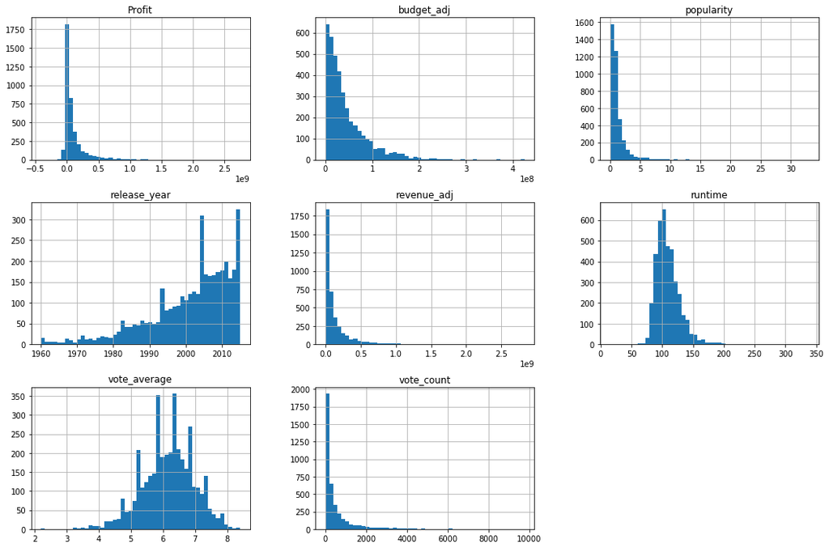

```python
df.hist(figsize = (18,12), bins=50);
```

### Helper functions

```python
def Line_plot(title, xlabel, ylabel, x, y):
    plt.figure(figsize=(18, 8))
    plt.plot(x, y);
    plt.title(title)
    plt.xlabel(xlabel)
    plt.ylabel(ylabel)
    # Draw trend line (fit the data points) to show the trend of the relation between the two varibles.
    coeff = np.polyfit(x, y, 1)
    plt.plot(x, np.polyval(coeff, x), color='red');
```

```python
def Scatter_plot(x, y):
    df.plot(x=x, y=y, kind='scatter');
    plt.title(str(x) + ' vs ' + str(y))
    # Draw trend line (fit the data points) to show the trend of the relation between the two varibles.
    coeff = np.polyfit(df[x], df[y], 1)
    plt.plot(df[x], np.polyval(coeff, df[x]), color='red');
```

```python
def Bar_plot(title, xlabel, ylabel, x, y):
    plt.figure(figsize=(18, 8))
    plt.bar(x, y);
    plt.xticks(rotation=90)
    plt.title(title)
    #set the xlabel and y label of the figure
    plt.xlabel(xlabel)
    plt.ylabel(ylabel)
```

### Release years distribution

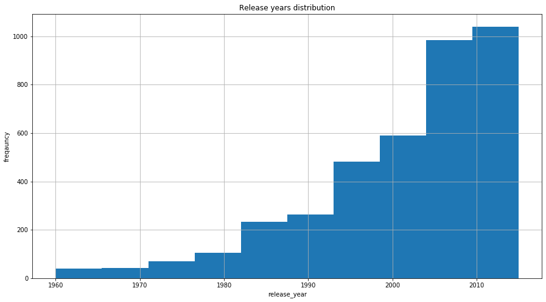

```python
plt.figure(figsize=(15, 8))
df['release_year'].hist();
plt.xlabel('release_year')
plt.ylabel('freqauncy')
plt.title('Release years distribution');
```

> As we see number of movies incresed with years.

### Genres distribution in the DataSet

> Find the most frequent genres in the dataset.

```python
# calc each genres freqauncy in data set and store it in list to plot.
genres_freqauncy = []
for i in genres:
    genres_freqauncy.append(df['genres'].str.contains(i).sum())
```

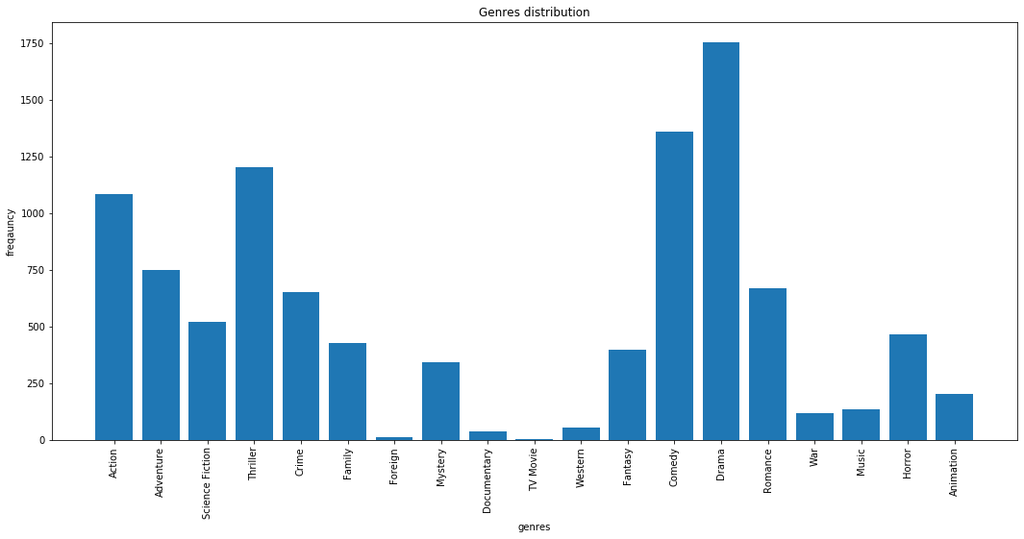

```python
Bar_plot('Genres distribution', 'genres', 'freqauncy', genres, genres_freqauncy)
```

> As we see most of the movies in the dataset are considered as Drama/Comedy/Thriller.

### Calculate mean data for some genres features related to questions

```python
# loop in each genre and calc mean  for each of the features in below list.
# genres_mean_info is matrix.
col = ['popularity', 'runtime', 'vote_average', 'budget_adj', 'revenue_adj', 'Profit']
genres_mean_info = []
for i in col:
    temp = []
    for j in genres:
        temp.append(df[df['genres'].str.contains(j)][i].mean())
    genres_mean_info.append(temp)

genres_mean_info = np.array(genres_mean_info)
genres_mean_info.shape
```

```
(6, 19)
```

### What genres are the Most Popular?

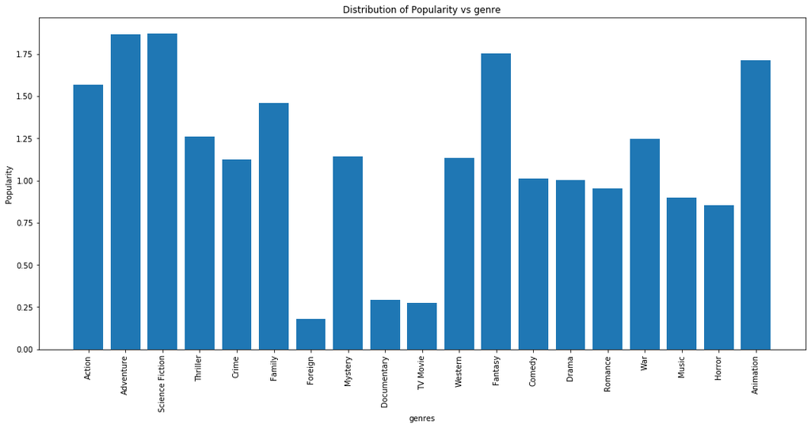

```python
Bar_plot('Distribution of Popularity vs genre', 'genres', 'Popularity', genres, genres_mean_info[0])
```

> As we see the most popular movie geners is fantasy/Animation/Sci-Fi/Adventure.

### What genres have the longest and shortest runtime?

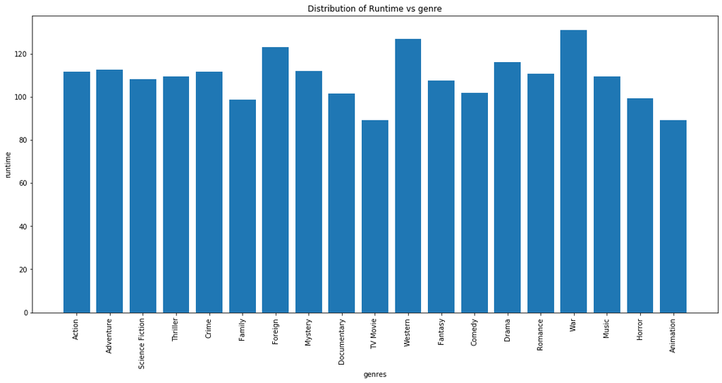

```python
Bar_plot('Distribution of Runtime vs genre', 'genres', 'runtime', genres, genres_mean_info[1])
```

### What genres have the highest rate?

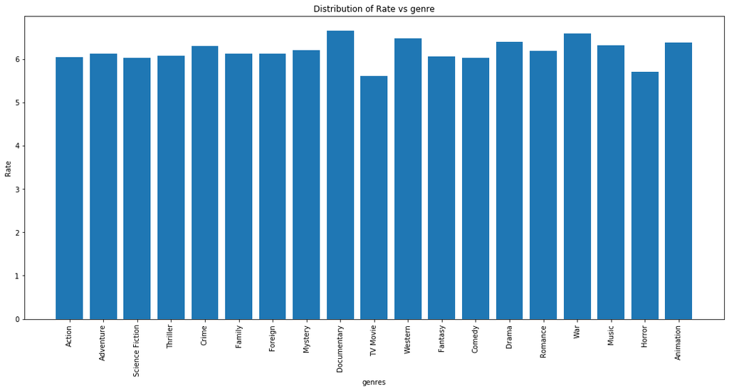

```python
Bar_plot('Distribution of Rate vs genre', 'genres', 'Rate', genres, genres_mean_info[2])
```

> As we see the highest rate geners is Documantry and War movies.

### What genres have the highest budget?

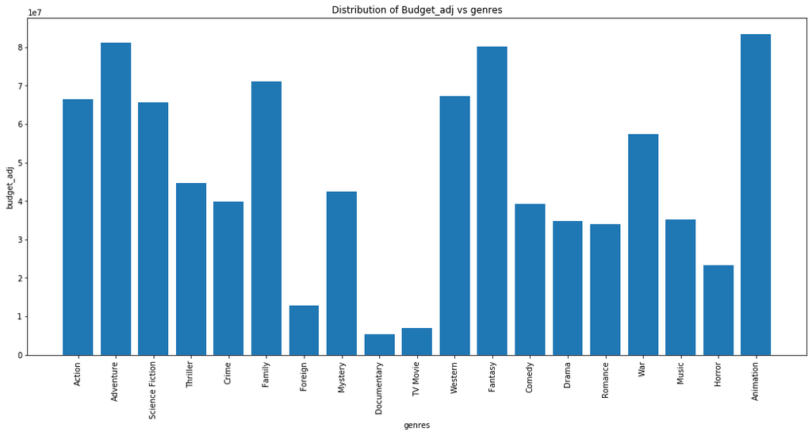

```python
Bar_plot('Distribution of Budget_adj vs genres', 'genres', 'budget_adj', genres, genres_mean_info[3])
```

> As we see the highest budget movies is Animation/Adventuare/Fantasy.

### What genres have the highest revenue?

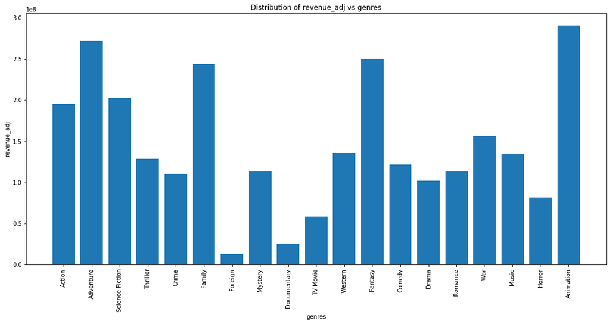

```python
Bar_plot('Distribution of revenue_adj vs genres', 'genres', 'revenue_adj', genres, genres_mean_info[4])
```

> As we see the highest revenue movies is Animation/Adventuare/Fantasy.

### What genres have the highest profit?

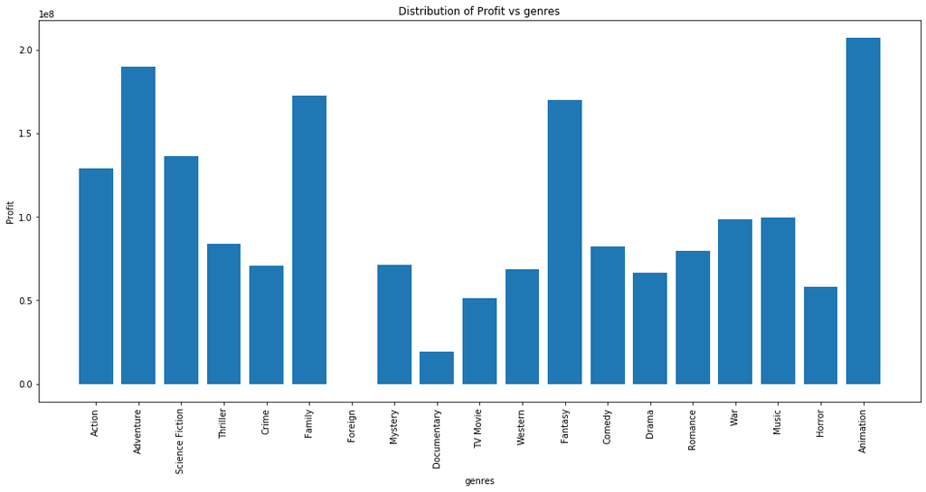

```python
Bar_plot('Distribution of Profit vs genres', 'genres', 'Profit', genres, genres_mean_info[5])
```

> As we see the highest profit movies is Animation/Adventuare/Fantasy/Family.

### Relation between popularity and profit?

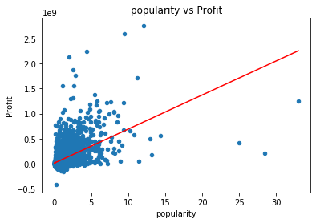

```python
Scatter_plot('popularity', 'Profit')
```

> As we see there is a positive relationship between popularity and profit (upward trend line).

### Relation between Rate and profit?

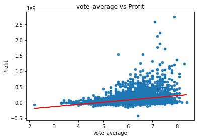

```python
Scatter_plot('vote_average', 'Profit')
```

> There is a allmost positive relationship between Rate and profit.

### Relation between budget and profit?

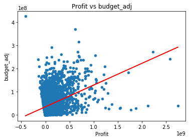

```python
Scatter_plot('Profit', 'budget_adj')
```

> There is a positive relationship between budget and profit (upward trend line).

### Is the movie industry profit increase with years?

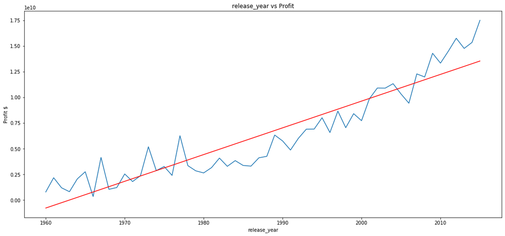

```python
years_profit = []
for i in release_years:
    years_profit.append(df.query('release_year == ' + str(i)).Profit.sum())

Line_plot('release_year vs Profit', 'release_year', 'Profit $', release_years, years_profit)
```

> the movies indusrty is get more proftiable with years (upward trend line).

### What is the relation between budget and release years?

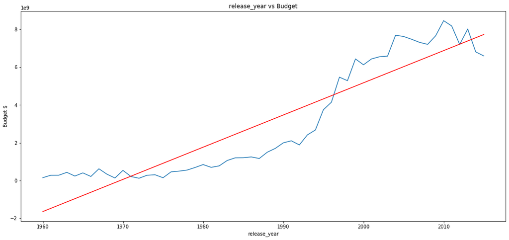

```python
years_budget = []
for i in release_years:
    years_budget.append(df.query('release_year == ' + str(i)).budget_adj.sum())

Line_plot('release_year vs Budget', 'release_year', 'Budget $', release_years, years_budget)
```

> As we see with time the budget of movies incresing (upward trend line).

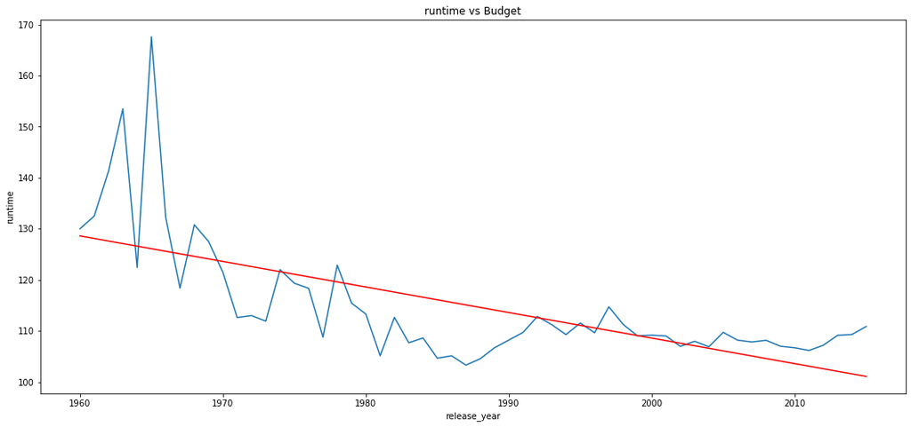

```python
years_runTime = []
for i in release_years:
    years_runTime.append(df.query('release_year == ' + str(i)).runtime.mean())

Line_plot('runtime vs Budget', 'release_year', 'runtime', release_years, years_runTime)
```

> As we see the runtime decrease with years (downward trend line).

### Average profit of movies?

```python
avg_profit = df['Profit'].mean()
avg_profit
```

```
92824697.2230982
```

> So to consider the movie successful it must have a profit above 92 million dollars.

### Average Budget of successful movies?

```python
df.query('Profit >= ' + str(avg_profit))['budget_adj'].mean()
```

```
74644141.48959233
```

> So the movies having a profit of 92 million dollars and more have an average budget of 74 million dollars.

## Conclusions

> Most popular movie genres is advuature/sci-fi/animation/fantasy.  
> Most profitable movie genres are adventure/family/animation/fantasy.  
> Documanrty/War movies have the highest rate.  
> There is a positive relationship between popularity and profit.  
> There is a positive relationship between rate and profit.  
> There is a positive relationship between budget and profit.  
> There is a negative relationship between runtime and release years.

### Limitation

> There are many information removed such as rows contained 0 values and null values. The dataset was cut by a few thousand rows of movies, which would definitely affect the result.  
> The genres of the movies are not very accurate because most movies considered in more than one genre.  
> Every movie has diffrent number of votes. Therefore, movies with fewer votes or higher votes would not be very accurate.